# STAT364 Data Science Estimation Homework 1 (R)

Kira Novitchkova-Burbank

# Problem 1: The dataset teengamb concerns a study of teenage gambling in Britain. Fit a regression model with the expenditure on gambling as the response and the sex, status, income and verbal score as predictors. Present the output.

## Question a: What percentage of variation in the response is explained by these predictors?

Your code:

```r
library(faraway)
data(teengamb)

#start of my code
data(teengamb, package = "faraway")
summary(teengamb)
```

```
##       sex             status          income           verbal
##  Min.   :0.0000   Min.   :18.00   Min.   : 0.600   Min.   : 1.00
##  1st Qu.:0.0000   1st Qu.:28.00   1st Qu.: 2.000   1st Qu.: 6.00
##  Median :0.0000   Median :43.00   Median : 3.250   Median : 7.00
##  Mean   :0.4043   Mean   :45.23   Mean   : 4.642   Mean   : 6.66
##  3rd Qu.:1.0000   3rd Qu.:61.50   3rd Qu.: 6.210   3rd Qu.: 8.00
##  Max.   :1.0000   Max.   :75.00   Max.   :15.000   Max.   :10.00
##      gamble
##  Min.   :  0.0
##  1st Qu.:  1.1
##  Median :  6.0
##  Mean   : 19.3
##  3rd Qu.: 19.4
##  Max.   :156.0
```

```r
lmod <- lm(gamble ~ sex + status + income + verbal, data=teengamb)
summary(lmod)
```

```
##
## Call:
## lm(formula = gamble ~ sex + status + income + verbal, data = teengamb)
##
## Residuals:
##     Min      1Q  Median      3Q     Max
## -51.082 -11.320  -1.451   9.452  94.252
##
## Coefficients:
##              Estimate Std. Error t value Pr(>|t|)
## (Intercept)  22.55565   17.19680   1.312   0.1968
## sex         -22.11833    8.21111  -2.694   0.0101 *
## status        0.05223    0.28111   0.186   0.8535
## income        4.96198    1.02539   4.839 1.79e-05 ***
## verbal       -2.95949    2.17215  -1.362   0.1803
## ---
## Signif. codes:  0 '***' 0.001 '**' 0.01 '*' 0.05 '.' 0.1 ' ' 1
##
## Residual standard error: 22.69 on 42 degrees of freedom
## Multiple R-squared:  0.5267, Adjusted R-squared:  0.4816
## F-statistic: 11.69 on 4 and 42 DF,  p-value: 1.815e-06
```

Your code:

```r
#finding r_squared
r_squared <- summary(lmod)$r.squared
print(paste("r_squared: ", r_squared))
```

```
## [1] "r_squared:  0.526723412826738"
```

Your answer: 52.67% of the variation in the y values is explained by the x values.

**Put your answer, explanation, findings here**

## Question b: Which observation has the largest (positive) residual? Give the case number.

Your code:

```r
#pulling just residuals
teengamb$residuals <- lmod$residuals

#finding what the max value is
max <- max(teengamb$residuals)
print(paste("max value: ", max))
```

```
## [1] "max value:  94.2522174243443"
```

```r
#finding the index value also known as the case number for the max value
max_index <- which(teengamb$residuals == max)
print(paste("case number: ", max_index))
```

```
## [1] "case number:  24"
```

Your answer: The observation with the largest (positive) residual is case number 24.

**Put your answer, explanation, findings here**

## Question c: Compute the mean and median of the residuals.

Your code:

```r
#finding mean of a residual
mean_residual <- mean(teengamb$residuals)
print(paste("mean value: ", mean_residual))
```

```
## [1] "mean value:  -1.55691431968918e-16"
```

```r
#finding median of a residual
median_residual <- median(teengamb$residuals)
print(paste("median value: ", median_residual))
```

```
## [1] "median value:  -1.45139206896953"
```

Your answer: The mean of the residuals is -1.55691431968918e-16. The median of the residuals is -1.45139206896953.

**Put your answer, explanation, findings here**

## Question d: Compute the correlation of the residuals with the fitted values.

Your code:

```r
#residuals
print("teengamb$residuals")
```

```
## [1] "teengamb$residuals"
```

```r
print(teengamb$residuals)
```

```
##  [1]  10.6507430   9.3711318   5.4630298 -17.4957487  29.5194692  -2.9846919
##  [7]  -7.0242994 -12.3060734   6.8496267 -10.3329505   1.5934936  -3.0958161
## [13]   0.1172839   9.5331344   2.8488167  17.2107726 -25.2627227 -27.7998544
## [19]  13.1446553 -15.9510624 -16.0041386  -9.5801478 -27.2711657  94.2522174
## [25]   0.6993361  -9.1670510 -25.8747696  -8.7455549  -6.8803097 -19.8090866
## [31]  10.8793766  15.0599340  11.7462296  -3.5932770 -14.4016736  45.6051264
## [37]  20.5472529  11.2429290 -51.0824078   8.8669438  -1.4513921  -3.8361619
## [43]  -4.3831786 -14.8940753   5.4506347   1.4092321   7.1662399
```

```r
#fitted values
teengamb$fitted_values <- lmod$fitted.values
cat("\nteengamb$fitted_values") #cat so that the new line would work
```

```
##
## teengamb$fitted_values
```

```r
print(teengamb$fitted_values)
```

```
##  [1] -10.6507430  -9.3711318  -5.4630298  24.7957487  -9.9194692   3.0846919
##  [7]   8.4742994  18.9060734  -5.1496267  10.4329505  -1.4934936   8.4958161
## [13]   1.0827161  -5.9331344  -0.4488167 -13.8107726  25.3627227  36.1998544
## [19]  -1.1446553  15.9510624  17.0041386  10.7801478  27.3711657  61.7477826
## [25]  37.8006639  11.2670510  40.3747696  11.7455549   7.4803097  29.4090866
## [31]  77.1206234  38.1400660  78.2537704   6.5932770  28.5016736  24.3948736
## [37]  17.9527471  45.9570710  57.0824078  16.1330562   8.3513921  73.5361619
## [43]  17.6831786  15.4940753  32.5493653  12.9907679  12.0337601
```

```r
#correlation between residuals and fitted values
correlation <- cor(teengamb$residuals, teengamb$fitted_values)
print(paste("correlation", correlation))
```

```
## [1] "correlation -6.21582345743482e-17"
```

Your answer: The correlation of the residuals with the fitted values is -6.21582345743482e-17.

**Put your answer, explanation, findings here**

## Question e: Compute the correlation of the residuals with the income.

Your code:

```r
#correlation between residuals and income
correlation <- cor(teengamb$residuals, teengamb$income)
print(paste("correlation", correlation))
```

```
## [1] "correlation 3.24705779690709e-17"
```

Your answer: The correlation of the residuals with the income is 3.24705779690709e-17.

**Put your answer, explanation, findings here**

## Question f: For all other predictors held constant, what would be the difference in predicted expenditure on gambling for a male compared to a female?

Your code:

```r
teengamb_coef <- lmod$coefficients['sex'] #taking the coefficient for 'sex' because that is what we're interested in
print(paste("coefficient for predictor 'sex':", teengamb_coef))
```

```
## [1] "coefficient for predictor 'sex': -22.1183300928389"
```

Your answer: The difference in predicted expenditure on gambling for a male compared to a female is -22.11833 which is the coefficient for ‘sex’, but I don’t know what it means yet in the context of male vs female and their gambling habits.

**Put your answer, explanation, findings here**

# Problem 2: The dataset uswages is drawn as a sample from the Current Population Survey in 1988. Fit a model with weekly wages as the response and years of education and experience as predictors. Report and give a simple interpretation to the regression coefficient for years of education. Now fit the same model but with logged weekly wages. Give an interpretation to the regression coefficient for years of education. Which interpretation is more natural?

Your code:

```r
data(uswages, package = "faraway")
summary(uswages)
```

```
##       wage              educ           exper            race
##  Min.   :  50.39   Min.   : 0.00   Min.   :-2.00   Min.   :0.000
##  1st Qu.: 308.64   1st Qu.:12.00   1st Qu.: 8.00   1st Qu.:0.000
##  Median : 522.32   Median :12.00   Median :15.00   Median :0.000
##  Mean   : 608.12   Mean   :13.11   Mean   :18.41   Mean   :0.078
##  3rd Qu.: 783.48   3rd Qu.:16.00   3rd Qu.:27.00   3rd Qu.:0.000
##  Max.   :7716.05   Max.   :18.00   Max.   :59.00   Max.   :1.000
##       smsa             ne              mw               so
##  Min.   :0.000   Min.   :0.000   Min.   :0.0000   Min.   :0.0000
##  1st Qu.:1.000   1st Qu.:0.000   1st Qu.:0.0000   1st Qu.:0.0000
##  Median :1.000   Median :0.000   Median :0.0000   Median :0.0000
##  Mean   :0.756   Mean   :0.229   Mean   :0.2485   Mean   :0.3125
##  3rd Qu.:1.000   3rd Qu.:0.000   3rd Qu.:0.0000   3rd Qu.:1.0000
##  Max.   :1.000   Max.   :1.000   Max.   :1.0000   Max.   :1.0000
##        we             pt
##  Min.   :0.00   Min.   :0.0000
##  1st Qu.:0.00   1st Qu.:0.0000
##  Median :0.00   Median :0.0000
##  Mean   :0.21   Mean   :0.0925
##  3rd Qu.:0.00   3rd Qu.:0.0000
##  Max.   :1.00   Max.   :1.0000
```

Weekly Wages Model:

```r
lmod <- lm(wage ~ educ + exper, data = uswages)
summary(lmod)
```

```
##
## Call:
## lm(formula = wage ~ educ + exper, data = uswages)
##
## Residuals:
##     Min      1Q  Median      3Q     Max
## -1018.2  -237.9   -50.9   149.9  7228.6
##
## Coefficients:
##              Estimate Std. Error t value Pr(>|t|)
## (Intercept) -242.7994    50.6816  -4.791 1.78e-06 ***
## educ          51.1753     3.3419  15.313  < 2e-16 ***
## exper          9.7748     0.7506  13.023  < 2e-16 ***
## ---
## Signif. codes:  0 '***' 0.001 '**' 0.01 '*' 0.05 '.' 0.1 ' ' 1
##
## Residual standard error: 427.9 on 1997 degrees of freedom
## Multiple R-squared:  0.1351, Adjusted R-squared:  0.1343
## F-statistic:   156 on 2 and 1997 DF,  p-value: < 2.2e-16
```

```r
teengamb_coef <- lmod$coefficients['educ']
print(paste("coefficient for predictor 'educ':", teengamb_coef))
```

```
## [1] "coefficient for predictor 'educ': 51.1752675791409"
```

```r
r_squared <- summary(lmod)$r.squared
print(paste("weekly wages model r_squared:", r_squared))
```

```
## [1] "weekly wages model r_squared: 0.135118568291978"
```

Logged Weekly Wages:

```r
lmod <- lm(log(wage) ~ educ + exper, data = uswages)
summary(lmod)
```

```
##
## Call:
## lm(formula = log(wage) ~ educ + exper, data = uswages)
##
## Residuals:
##     Min      1Q  Median      3Q     Max
## -2.7533 -0.3495  0.1068  0.4381  3.5699
##
## Coefficients:
##             Estimate Std. Error t value Pr(>|t|)
## (Intercept) 4.650319   0.078354   59.35   <2e-16 ***
## educ        0.090506   0.005167   17.52   <2e-16 ***
## exper       0.018079   0.001160   15.58   <2e-16 ***
## ---
## Signif. codes:  0 '***' 0.001 '**' 0.01 '*' 0.05 '.' 0.1 ' ' 1
##
## Residual standard error: 0.6615 on 1997 degrees of freedom
## Multiple R-squared:  0.1749, Adjusted R-squared:  0.174
## F-statistic: 211.6 on 2 and 1997 DF,  p-value: < 2.2e-16
```

```r
teengamb_coef <- lmod$coefficients['educ']
print(paste("coefficient for predictor 'educ':", teengamb_coef))
```

```
## [1] "coefficient for predictor 'educ': 0.0905062802532166"
```

```r
r_squared <- summary(lmod)$r.squared
print(paste("logged weekly wages model r_squared:", r_squared))
```

```
## [1] "logged weekly wages model r_squared: 0.174860535404239"
```

Your answer: Look at R^2 of both models and see which one is better. Weekly wages model r_squared is 0.135118568291978. Logged weekly wages model r_squared is 0.174860535404239. The better model should have R^2 be closer to 1. So, the logged weekly model is better because its R^2 is closer to 1.

**Put your answer, explanation, findings here**

# Problem 4: The dataset prostate comes from a study on 97 men with prostate cancer who were due to receive a radical prostatectomy. Fit a model with lpsa as the response and lcavol as the predictor. Record the residual standard error and the R2. Now add lweight, svi, lbph, age, lcp, pgg45 and gleason to the model one at a time. For each model record the residual standard error and the R2. Plot the trends in these two statistics.

Your code:

```r
data(prostate, package = "faraway")
summary(prostate)
```

```
##      lcavol           lweight           age             lbph
##  Min.   :-1.3471   Min.   :2.375   Min.   :41.00   Min.   :-1.3863
##  1st Qu.: 0.5128   1st Qu.:3.376   1st Qu.:60.00   1st Qu.:-1.3863
##  Median : 1.4469   Median :3.623   Median :65.00   Median : 0.3001
##  Mean   : 1.3500   Mean   :3.653   Mean   :63.87   Mean   : 0.1004
##  3rd Qu.: 2.1270   3rd Qu.:3.878   3rd Qu.:68.00   3rd Qu.: 1.5581
##  Max.   : 3.8210   Max.   :6.108   Max.   :79.00   Max.   : 2.3263
##       svi              lcp             gleason          pgg45
##  Min.   :0.0000   Min.   :-1.3863   Min.   :6.000   Min.   :  0.00
##  1st Qu.:0.0000   1st Qu.:-1.3863   1st Qu.:6.000   1st Qu.:  0.00
##  Median :0.0000   Median :-0.7985   Median :7.000   Median : 15.00
##  Mean   :0.2165   Mean   :-0.1794   Mean   :6.753   Mean   : 24.38
##  3rd Qu.:0.0000   3rd Qu.: 1.1786   3rd Qu.:7.000   3rd Qu.: 40.00
##  Max.   :1.0000   Max.   : 2.9042   Max.   :9.000   Max.   :100.00
##       lpsa
##  Min.   :-0.4308
##  1st Qu.: 1.7317
##  Median : 2.5915
##  Mean   : 2.4784
##  3rd Qu.: 3.0564
##  Max.   : 5.5829
```

lpsa ~ lcavol

```r
lmod <- lm(lpsa ~ lcavol, data = prostate)
lmod
```

```
##
## Call:
## lm(formula = lpsa ~ lcavol, data = prostate)
##
## Coefficients:
## (Intercept)       lcavol
##      1.5073       0.7193
```

```r
standard_error <- summary(lmod)$sigma
standard_error_trendline <- c() #making a vector
standard_error_trendline <- c(standard_error_trendline, standard_error) #need to have the previous values (standard_error_trendline) still in the vector when you put the new value (standard_error) into the vector
print("standard_error_trendline") #will have residual standard error values
```

```
## [1] "standard_error_trendline"
```

```r
print(standard_error_trendline)
```

```
## [1] 0.7874994
```

```r
r_squared <- summary(lmod)$r.squared
r_squared_trendline <- c()
r_squared_trendline <- c(r_squared_trendline, r_squared)
print("r_squared_trendline") #will have r squared values
```

```
## [1] "r_squared_trendline"
```

```r
print(r_squared_trendline)
```

```
## [1] 0.5394319
```

lpsa ~ lcavol + lweight

```r
lmod <- lm(lpsa ~ lcavol + lweight, data = prostate)
lmod
```

```
##
## Call:
## lm(formula = lpsa ~ lcavol + lweight, data = prostate)
##
## Coefficients:
## (Intercept)       lcavol      lweight
##     -0.3026       0.6775       0.5109
```

```r
standard_error <- summary(lmod)$sigma
standard_error_trendline <- c(standard_error_trendline, standard_error)
print("standard_error_trendline")
```

```
## [1] "standard_error_trendline"
```

```r
print(standard_error_trendline)
```

```
## [1] 0.7874994 0.7506469
```

```r
r_squared <- summary(lmod)$r.squared
r_squared_trendline <- c(r_squared_trendline, r_squared)
print("r_squared_trendline")
```

```
## [1] "r_squared_trendline"
```

```r
print(r_squared_trendline)
```

```
## [1] 0.5394319 0.5859345
```

lpsa ~ lcavol + lweight + svi

```r
lmod <- lm(lpsa ~ lcavol + lweight + svi, data = prostate)
lmod
```

```
##
## Call:
## lm(formula = lpsa ~ lcavol + lweight + svi, data = prostate)
##
## Coefficients:
## (Intercept)       lcavol      lweight          svi
##     -0.2681       0.5516       0.5085       0.6662
```

```r
standard_error <- summary(lmod)$sigma
standard_error_trendline <- c(standard_error_trendline, standard_error)
print("standard_error_trendline")
```

```
## [1] "standard_error_trendline"
```

```r
print(standard_error_trendline)
```

```
## [1] 0.7874994 0.7506469 0.7168094
```

```r
r_squared <- summary(lmod)$r.squared
r_squared_trendline <- c(r_squared_trendline, r_squared)
print("r_squared_trendline")
```

```
## [1] "r_squared_trendline"
```

```r
print(r_squared_trendline)
```

```
## [1] 0.5394319 0.5859345 0.6264403
```

```r
lmod <- lm(lpsa ~ lcavol + lweight + svi, data = prostate)
lmod
```

```
##
## Call:
## lm(formula = lpsa ~ lcavol + lweight + svi, data = prostate)
##
## Coefficients:
## (Intercept)       lcavol      lweight          svi
##     -0.2681       0.5516       0.5085       0.6662
```

```r
standard_error <- summary(lmod)$sigma
standard_error_trendline <- c(standard_error_trendline, standard_error)
print("standard_error_trendline")
```

```
## [1] "standard_error_trendline"
```

```r
print(standard_error_trendline)
```

```
## [1] 0.7874994 0.7506469 0.7168094 0.7168094
```

```r
r_squared <- summary(lmod)$r.squared
r_squared_trendline <- c(r_squared_trendline, r_squared)
print("r_squared_trendline")
```

```
## [1] "r_squared_trendline"
```

```r
print(r_squared_trendline)
```

```
## [1] 0.5394319 0.5859345 0.6264403 0.6264403
```

```r
lmod <- lm(lpsa ~ lcavol + lweight + svi + age, data = prostate)
lmod
```

```
##
## Call:
## lm(formula = lpsa ~ lcavol + lweight + svi + age, data = prostate)
##
## Coefficients:
## (Intercept)       lcavol      lweight          svi          age
##    0.171941     0.561925     0.546718     0.665046    -0.009287
```

```r
standard_error <- summary(lmod)$sigma
standard_error_trendline <- c(standard_error_trendline, standard_error)
print("standard_error_trendline")
```

```
## [1] "standard_error_trendline"
```

```r
print(standard_error_trendline)
```

```
## [1] 0.7874994 0.7506469 0.7168094 0.7168094 0.7176528
```

```r
r_squared <- summary(lmod)$r.squared
r_squared_trendline <- c(r_squared_trendline, r_squared)
print("r_squared_trendline")
```

```
## [1] "r_squared_trendline"
```

```r
print(r_squared_trendline)
```

```
## [1] 0.5394319 0.5859345 0.6264403 0.6264403 0.6295869
```

```r
lmod <- lm(lpsa ~ lcavol + lweight + svi + age + lcp, data = prostate)
lmod
```

```
##
## Call:
## lm(formula = lpsa ~ lcavol + lweight + svi + age + lcp, data = prostate)
##
## Coefficients:
## (Intercept)       lcavol      lweight          svi          age          lcp
##    0.149738     0.578260     0.544162     0.710112    -0.009377    -0.030615
```

```r
standard_error <- summary(lmod)$sigma
standard_error_trendline <- c(standard_error_trendline, standard_error)
print("standard_error_trendline")
```

```
## [1] "standard_error_trendline"
```

```r
print(standard_error_trendline)
```

```
## [1] 0.7874994 0.7506469 0.7168094 0.7168094 0.7176528 0.7210386
```

```r
r_squared <- summary(lmod)$r.squared
r_squared_trendline <- c(r_squared_trendline, r_squared)
print("r_squared_trendline")
```

```
## [1] "r_squared_trendline"
```

```r
print(r_squared_trendline)
```

```
## [1] 0.5394319 0.5859345 0.6264403 0.6264403 0.6295869 0.6301478
```

```r
lmod <- lm(lpsa ~ lcavol + lweight + svi + age + lcp + pgg45, data = prostate)
lmod
```

```
##
## Call:
## lm(formula = lpsa ~ lcavol + lweight + svi + age + lcp + pgg45,
##     data = prostate)
##
## Coefficients:
## (Intercept)       lcavol      lweight          svi          age          lcp
##    0.216172     0.583099     0.569477     0.687483    -0.014281    -0.099695
##       pgg45
##    0.005752
```

```r
standard_error <- summary(lmod)$sigma
standard_error_trendline <- c(standard_error_trendline, standard_error)
print("standard_error_trendline")
```

```
## [1] "standard_error_trendline"
```

```r
print(standard_error_trendline)
```

```
## [1] 0.7874994 0.7506469 0.7168094 0.7168094 0.7176528 0.7210386 0.7142174
```

```r
r_squared <- summary(lmod)$r.squared
r_squared_trendline <- c(r_squared_trendline, r_squared)
print("r_squared_trendline")
```

```
## [1] "r_squared_trendline"
```

```r
print(r_squared_trendline)
```

```
## [1] 0.5394319 0.5859345 0.6264403 0.6264403 0.6295869 0.6301478 0.6411003
```

```r
lmod <- lm(lpsa ~ lcavol + lweight + svi + age + lcp + pgg45 + gleason, data = prostate)
lmod
```

```
##
## Call:
## lm(formula = lpsa ~ lcavol + lweight + svi + age + lcp + pgg45 +
##     gleason, data = prostate)
##
## Coefficients:
## (Intercept)       lcavol      lweight          svi          age          lcp
##    -0.13015      0.57749      0.57625      0.69839     -0.01469     -0.10095
##       pgg45      gleason
##     0.00477      0.05576
```

```r
standard_error <- summary(lmod)$sigma
standard_error_trendline <- c(standard_error_trendline, standard_error)
print("standard_error_trendline")
```

```
## [1] "standard_error_trendline"
```

```r
print(standard_error_trendline)
```

```
## [1] 0.7874994 0.7506469 0.7168094 0.7168094 0.7176528 0.7210386 0.7142174
## [8] 0.7177256
```

```r
r_squared <- summary(lmod)$r.squared
r_squared_trendline <- c(r_squared_trendline, r_squared)
print("r_squared_trendline")
```

```
## [1] "r_squared_trendline"
```

```r
print(r_squared_trendline)
```

```
## [1] 0.5394319 0.5859345 0.6264403 0.6264403 0.6295869 0.6301478 0.6411003
## [8] 0.6415929
```

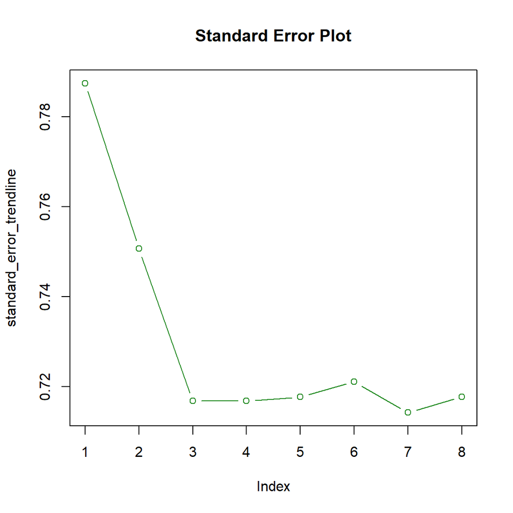

```r
#Note: type means display the data as line and/or point. l means (display line only), p (show point only) and b (show both)
plot(standard_error_trendline, main = "Standard Error Plot", type = "b", col = "forestgreen")
```

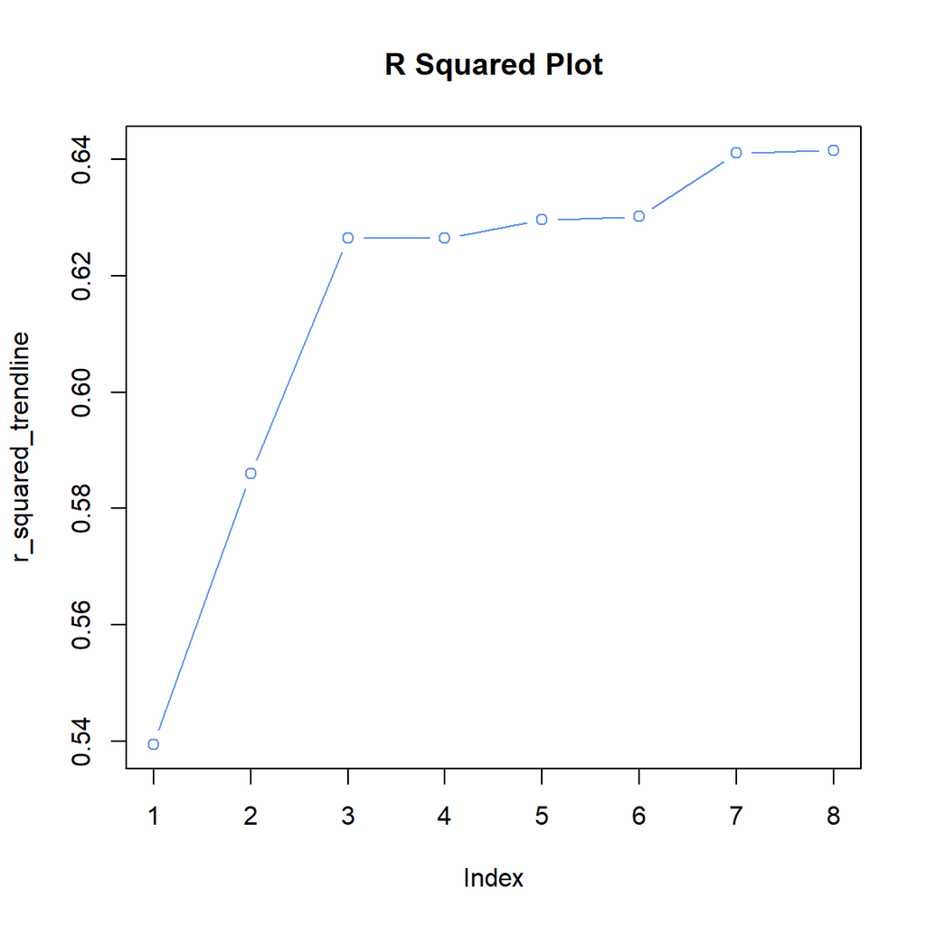

```r
plot(r_squared_trendline, main = "R Squared Plot", type = "b", col = "cornflowerblue")
```

Your answer: Graphs above ^

**Put your answer, explanation, findings here**

# Problem 6: Thirty samples of cheddar cheese were analyzed for their content of acetic acid, hydrogen sulfide and lactic acid. Each sample was tasted and scored by a panel of judges and the average taste score produced. Use the cheddar data to answer the following:

```r
data(cheddar, package = "faraway")
summary(cheddar)
```

```
##      taste           Acetic           H2S             Lactic
##  Min.   : 0.70   Min.   :4.477   Min.   : 2.996   Min.   :0.860
##  1st Qu.:13.55   1st Qu.:5.237   1st Qu.: 3.978   1st Qu.:1.250
##  Median :20.95   Median :5.425   Median : 5.329   Median :1.450
##  Mean   :24.53   Mean   :5.498   Mean   : 5.942   Mean   :1.442
##  3rd Qu.:36.70   3rd Qu.:5.883   3rd Qu.: 7.575   3rd Qu.:1.667
##  Max.   :57.20   Max.   :6.458   Max.   :10.199   Max.   :2.010
```

## Question a: Fit a regression model with taste as the response and the three chemical contents as predictors. Report the values of the regression output.

Your code:

```r
lmod <- lm(taste ~ Acetic + H2S + Lactic, data = cheddar)
summary(lmod)
```

```
##
## Call:
## lm(formula = taste ~ Acetic + H2S + Lactic, data = cheddar)
##
## Residuals:
##     Min      1Q  Median      3Q     Max
## -17.390  -6.612  -1.009   4.908  25.449
##
## Coefficients:
##             Estimate Std. Error t value Pr(>|t|)
## (Intercept) -28.8768    19.7354  -1.463  0.15540
## Acetic        0.3277     4.4598   0.073  0.94198
## H2S           3.9118     1.2484   3.133  0.00425 **
## Lactic       19.6705     8.6291   2.280  0.03108 *
## ---
## Signif. codes:  0 '***' 0.001 '**' 0.01 '*' 0.05 '.' 0.1 ' ' 1
##
## Residual standard error: 10.13 on 26 degrees of freedom
## Multiple R-squared:  0.6518, Adjusted R-squared:  0.6116
## F-statistic: 16.22 on 3 and 26 DF,  p-value: 3.81e-06
```

Your answer: Above in summary ^

**Put your answer, explanation, findings here**

## Question b: Compute the correlation between the fitted values and the response. Square it. Identify where this value appears in the regression output.

Your code:

```r
cheddar$fitted_values <- lmod$fitted.values
print("cheddar$fitted_values")
```

```
## [1] "cheddar$fitted_values"
```

```r
print(cheddar$fitted_values)
```

```
##  [1]  1.792448 22.637394 25.037235 37.937537  7.017705 24.165169 32.564008
##  [8] 39.290535 13.164096 20.248733 30.077506 41.544722  5.161180 17.743309
## [15] 29.451144 44.942781 10.813081 20.591729 29.057581 47.506796 14.599868
## [22] 19.441237 37.389877 52.476815 12.983288 14.414981 34.307356 12.760737
## [29] 20.419630 16.461523
```

```r
correlation <- cor(cheddar$fitted_values, cheddar$taste)
print(paste("correlation:", correlation))
```

```
## [1] "correlation: 0.807325640511167"
```

```r
correlation_squared <- correlation ** 2
print(paste("correlation_squared:", correlation_squared))
```

```
## [1] "correlation_squared: 0.651774689826766"
```

Your answer: Seems like it is Multiple R-squared.

**Put your answer, explanation, findings here**

## Question c: Fit the same regression model but without an intercept term. What is the value of R^2 reported in the output? Compute a more reasonable measure of the goodness of fit for this example.

Model without intercept:

Your code:

```r
lmod <- lm(taste ~ 0 + Acetic + H2S + Lactic, data = cheddar) #now B0 = 0 which removes the intercept
summary(lmod)
```

```
##
## Call:
## lm(formula = taste ~ 0 + Acetic + H2S + Lactic, data = cheddar)
##
## Residuals:
##      Min       1Q   Median       3Q      Max
## -15.4521  -6.5262  -0.6388   4.6811  28.4744
##
## Coefficients:
##        Estimate Std. Error t value Pr(>|t|)
## Acetic   -5.454      2.111  -2.583  0.01553 *
## H2S       4.576      1.187   3.854  0.00065 ***
## Lactic   19.127      8.801   2.173  0.03871 *
## ---
## Signif. codes:  0 '***' 0.001 '**' 0.01 '*' 0.05 '.' 0.1 ' ' 1
##
## Residual standard error: 10.34 on 27 degrees of freedom
## Multiple R-squared:  0.8877, Adjusted R-squared:  0.8752
## F-statistic: 71.15 on 3 and 27 DF,  p-value: 6.099e-13
```

```r
r_squared <- summary(lmod)$r.square #value of R^2
print(paste("r_squared for model without intercept:", r_squared))
```

```
## [1] "r_squared for model without intercept: 0.887705930330882"
```

Model with intercept:

```r
lmod <- lm(taste ~ Acetic + H2S + Lactic, data = cheddar)
summary(lmod)
```

```
##
## Call:
## lm(formula = taste ~ Acetic + H2S + Lactic, data = cheddar)
##
## Residuals:
##     Min      1Q  Median      3Q     Max
## -17.390  -6.612  -1.009   4.908  25.449
##
## Coefficients:
##             Estimate Std. Error t value Pr(>|t|)
## (Intercept) -28.8768    19.7354  -1.463  0.15540
## Acetic        0.3277     4.4598   0.073  0.94198
## H2S           3.9118     1.2484   3.133  0.00425 **
## Lactic       19.6705     8.6291   2.280  0.03108 *
## ---
## Signif. codes:  0 '***' 0.001 '**' 0.01 '*' 0.05 '.' 0.1 ' ' 1
##
## Residual standard error: 10.13 on 26 degrees of freedom
## Multiple R-squared:  0.6518, Adjusted R-squared:  0.6116
## F-statistic: 16.22 on 3 and 26 DF,  p-value: 3.81e-06
```

```r
r_squared <- summary(lmod)$r.square #value of R^2
print(paste("r_squared for model with intercept:", r_squared))
```

```
## [1] "r_squared for model with intercept: 0.651774689826765"
```

Your answer: The value of R^2 for the model without the intercept is 0.8877059. The value of R^2 for the model with the intercept is 0.651774689826765. The model without the intercept has a better R^2 because its closer to 1.

**Put your answer, explanation, findings here**

## Question d: Compute the regression coefficents from the original fit using the QR decomposition showing your R code.

Your code:

Your answer: Don’t have to do this problem.

**Put your answer, explanation, findings here**